# Information Sharing Test

Ernesto Carrella

July 2, 2015

# Maximizing and Imitation

I’ve been experimenting with connecting fishers through a social network and using fisher friends to make decisions. Because right now the agents are very simple, their only real decision is where to go fishing.

Right now there are two adaptive strategies: * *HillClimbing*: Agents start with a preferred fishing spot. Every trip they try fishing somewhere else nearby, if the catch is better they move their preffered spot to this new location * *Exploration-Imitation*: Like hillclimbing but agents have a fixed probability of asking their friends where they go fishing and copy them instead.

The Exploration-Imitation strategy requires information sharing. The way information is shared is defined by the social network structure and in particular the number of edges between agents. As an example, the next plot shows how many simulation days it takes for 50 fishers to consume 95% of the available biomass in the model (the gear parameters as well as the logistic parameters of the biology are completely made up). There is a sweet spot of a few friends that make fishing most efficient. Gathering information from too many friends might be not optimal:

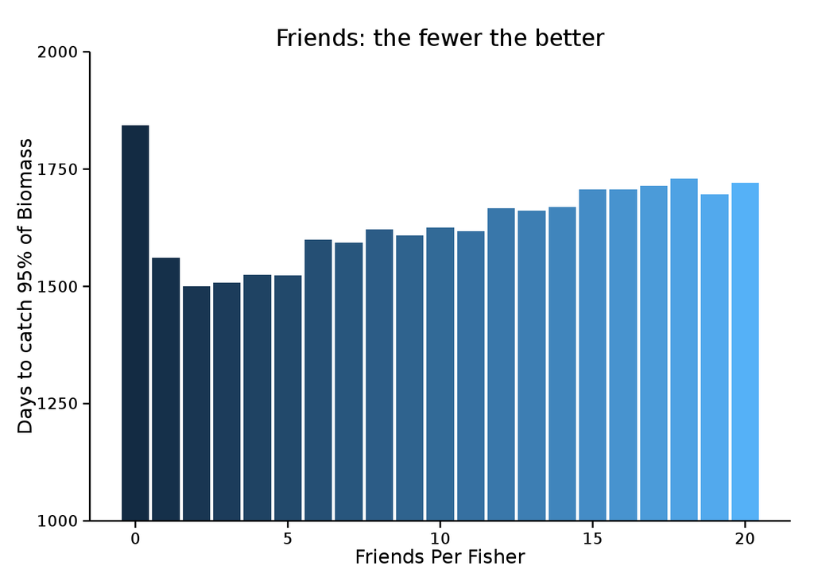

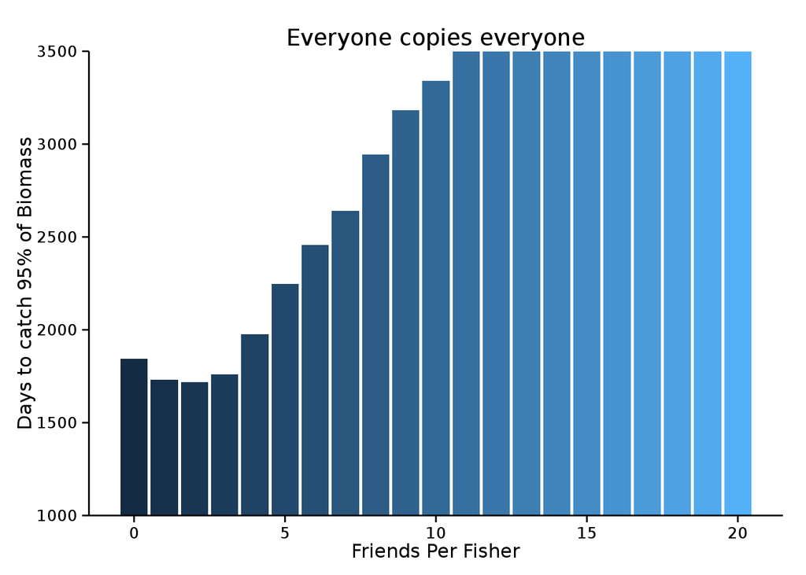

Now fishers use far more information from their friends but produce very little themselves which result in far less efficiency (I stopped the simulation after 3500 days so that’s a cutoff point). All these results are obviously subject to change as the biology becomes more interesting (currently using logistic cells like in the NETLOGO prototype but with a small yearly migration from cell to cell) and agents more nuanced.

It might also make sense to see the difference in dynamics that are created by the two different strategies. If all fishers are pure hill-climbers (no imitation, no friend) the dynamics look as follows (the redder the area, the more fished it is, clears automatically every simulation year):

[figure not shown]

Agents quickly start fishing near the port and then slowly move out farther and farther as the biomass close to port is exhausted. Notice the noise and dispersion though, fishers tend to go each their own way.

Compare to what happens if I force an 80% imitation chance and have each fisher have 15 friends:

[figure not shown]

Notice how boats tend to herd one another and they all converge on a few spots.